# Two-Way ANOVA - Week 6, Lecture 2

Author

Hector Gavilanes

```r
#install.packages("ggpubr")
library(ggpubr) # interaction plot
library(tidyverse)
library(gsheet)
library(ggstatsplot)
library(ISLR)
```

## Q1:

**Recall the advertising data from the last activity; you showed that there was an interaction between age and product type.**

**A large advertising firm specializes in creating television commercials for children’s products. The firm wants to design a study to investigate factors that may affect the lengths of time a commercial is able to hold a child’s attention. A preliminary study determines that two factors that may be important are the age of the child and the type of product being advertised. The firm wants to determine whether there were large differences in the mean length of time that the commercial is able to hold the child’s attention depending on these two factors. If there proves to be a difference, the firm would then attempt to determine new types of commercials depending on the product and targeted age group.**

```r
# clear environment
rm(list = ls())

# extract data
data <- as_tibble(gsheet2tbl("https://docs.google.com/spreadsheets/d/16_HOSmIBDD9oYY1oBQ5Df6eFH9nT6GgO1UWcbMZNLUo/edit?usp=sharing"))

# transform data
clean_data <- data %>%
  # delete empty rows
  drop_na() %>%
  rename("cereal_5-6" = "A1-P1") %>%
  rename("cereal_7-8" = "A2-P1") %>%
  rename("cereal_9-10" = "A3-P1") %>%
  rename("games_5-6" = "A1-P2") %>%
  rename("games_7-8" = "A2-P2") %>%
  rename("games_9-10" = "A3-P2")

# pivot to long data
prelong_data <- clean_data %>%
  pivot_longer(cols = c("cereal_5-6", "cereal_7-8", "cereal_9-10", "games_5-6", "games_7-8", "games_9-10"),
               names_to = "product_&_age",
               values_to = "Results")

# separate product and age into independent columns
separate_data <- prelong_data %>%
  separate(`product_&_age`, into = c("Product", "Age"), sep = "_")

# remove Child column
long_data <- within(separate_data, rm(Child))
```

1. Construct the profile plot for this data.

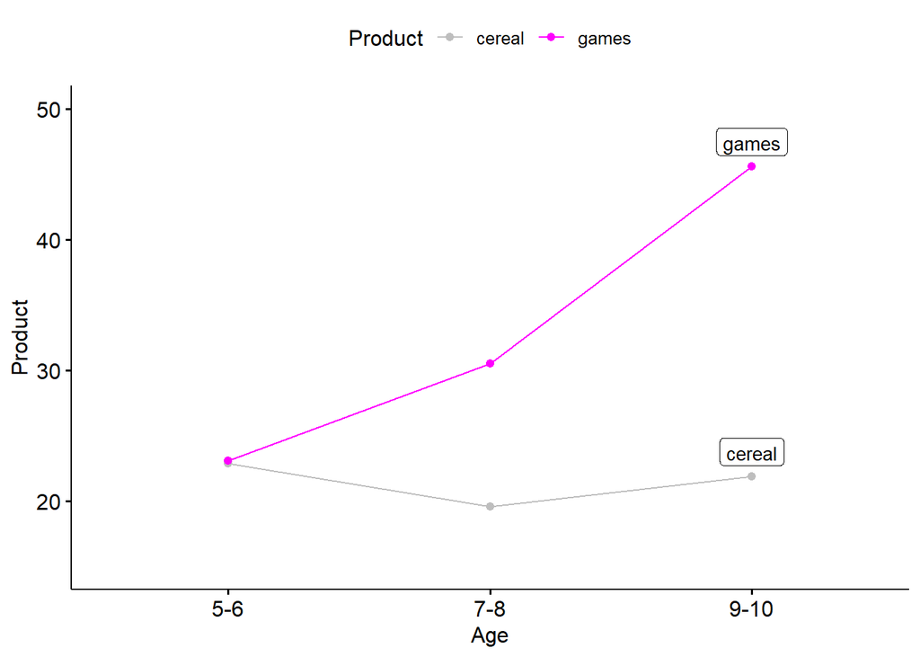

```r
# profile plot using ggline
profile <- ggline(long_data, x = "Age", y = "Results", color = "Product",
       add = "mean",
       show.line.label = TRUE,
       label.rectangle = TRUE,
       palette = c("gray", "magenta"),
       ylab = "Product")
profile_plot <- ggpar(profile, ylim = c(15, 50))
profile_plot
```

2. (Challenge!) Perform Tukey’s test to determine which treatment groups are significantly different. Test at the $\alpha=0.05$ level.

```r
# Two-way ANOVA
# Null Hypothesis:
# - H1: The means of observations grouped by Product are the same
# - H2: The means of observations grouped by Age are the same
# - H3: There is no interaction between Product and Age

summary(h1_h2 <- aov(long_data$Results ~ factor(long_data$Product) + factor(long_data$Age)))
```

```
                          Df Sum Sq Mean Sq F value   Pr(>F)
factor(long_data$Product)  1   2018  2018.4  12.117 0.000976 ***
factor(long_data$Age)      2   1303   651.5   3.911 0.025705 *
Residuals                 56   9328   166.6
---
Signif. codes:  0 '***' 0.001 '**' 0.01 '*' 0.05 '.' 0.1 ' ' 1
```

```r
# Product
TukeyHSD(h1_h2, "factor(long_data$Product)")
```

```
  Tukey multiple comparisons of means
    95% family-wise confidence level

Fit: aov(formula = long_data$Results ~ factor(long_data$Product) + factor(long_data$Age))

$`factor(long_data$Product)`
             diff      lwr      upr     p adj
games-cereal 11.6 4.924332 18.27567 0.0009757
```

### Tukey’s Test for Product

There is sufficient evidence at the $\alpha = 0.05$ level to suggest that the means of observations grouped by cereal and video games are different.

```r
# Age
TukeyHSD(h1_h2, "factor(long_data$Age)")
```

```
  Tukey multiple comparisons of means
    95% family-wise confidence level

Fit: aov(formula = long_data$Results ~ factor(long_data$Product) + factor(long_data$Age))

$`factor(long_data$Age)`
          diff        lwr      upr     p adj
7-8-5-6   2.05 -7.7761856 11.87619 0.8705131
9-10-5-6 10.75  0.9238144 20.57619 0.0289003
9-10-7-8  8.70 -1.1261856 18.52619 0.0925938
```

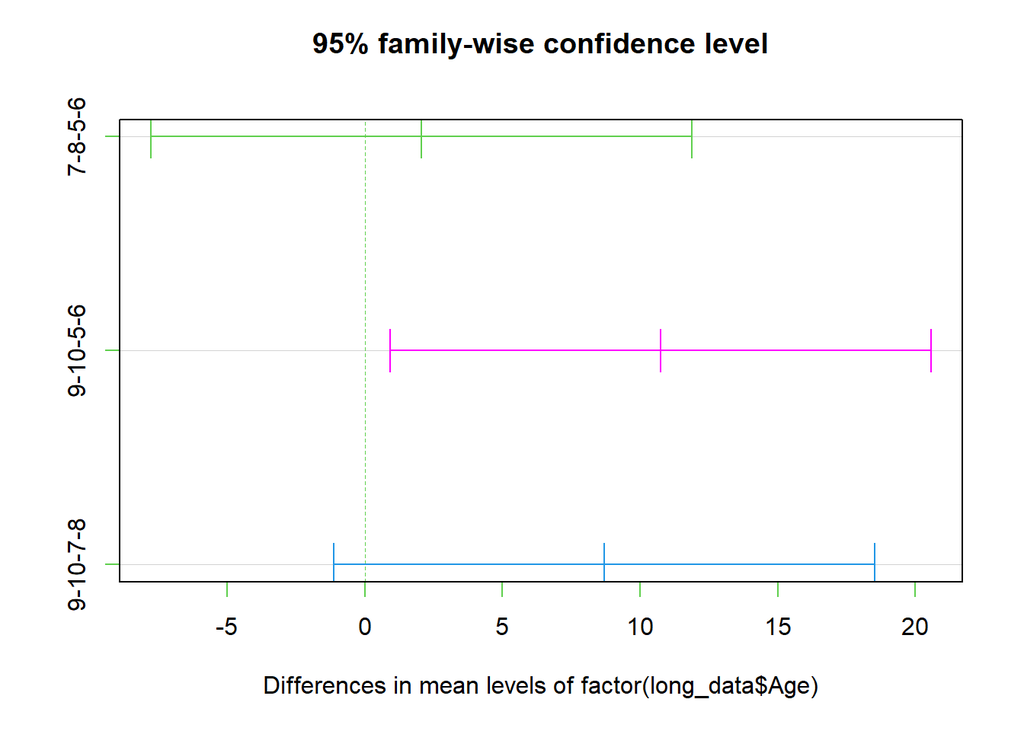

```r
plot(TukeyHSD(h1_h2, "factor(long_data$Age)"), col = c(3,"magenta",4))
```

### Tukey’s Test for Age groups

There is sufficient evidence at the $\alpha = 0.05$ level to suggest differences in the age groups’ means of observation. Furthermore, the main difference is between the ages of (5 to 6) and (9 to 10).

3. Write a short paragraph to explain your results to the advertising researchers.

## Conclusion

There is significant exponential interaction and main effects for both product and age groups. Our findings suggest that the kids spent more attention on advertisements for video games between the ages of 9 to 10.

4. Graphically assess the ANOVA assumptions – is ANOVA appropriate here?

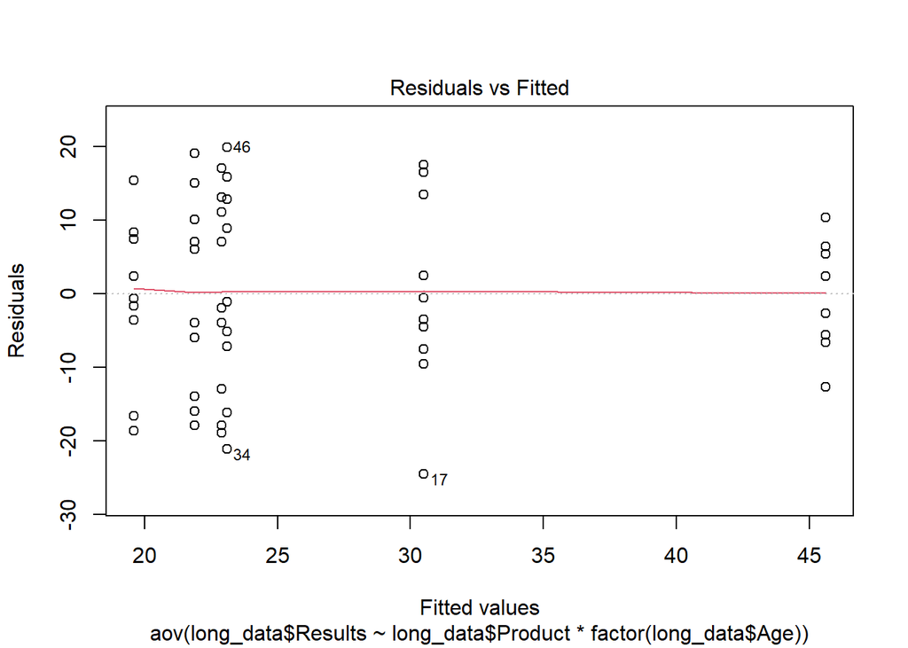

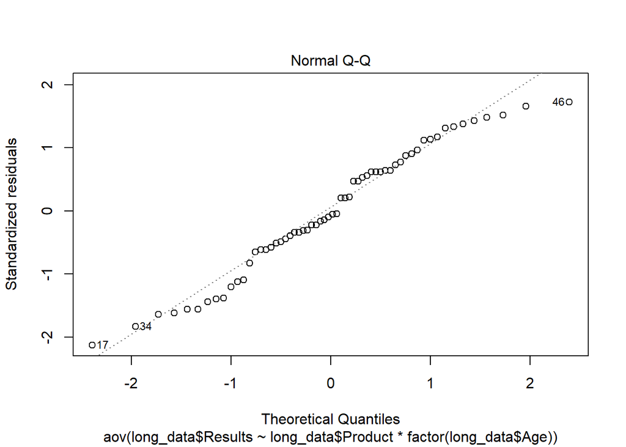

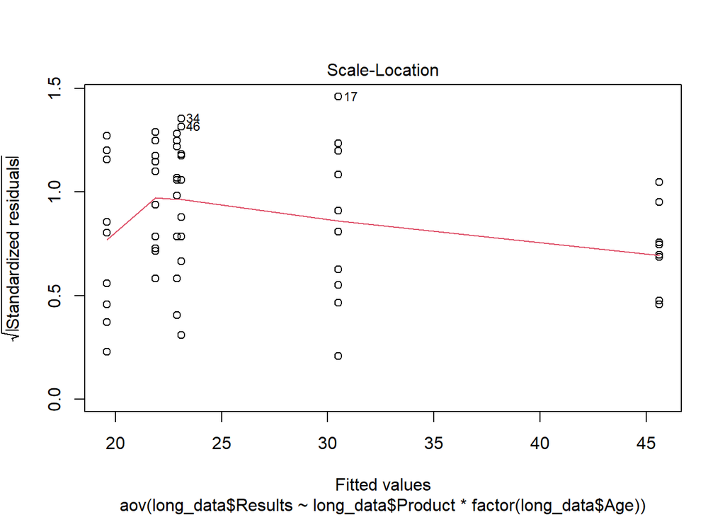

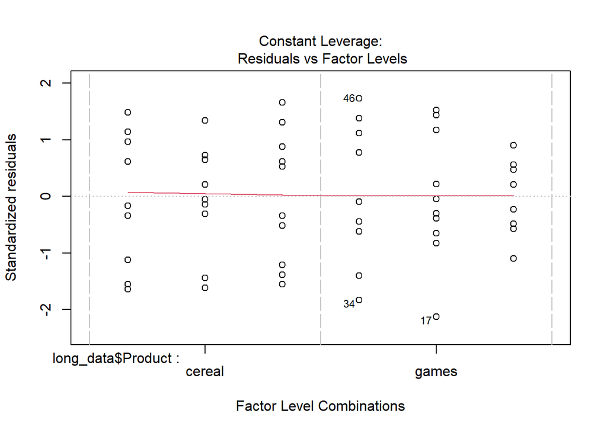

```r
h3 <- aov(long_data$Results ~ long_data$Product * factor(long_data$Age))
plot(h3)
```

## Q2:

**Recall the tomato data from the last activity; you showed that there was not an interaction between shading and phase of growth and that there was at least one main effect.**

**A horticulturalist at a large research institution designs a study to evaluate the effect on tomato yields of water loss due to transpiration. She decides to examine four levels of shading of the tomato plants at three stages of the tomato plant’s development. The four levels of shading (0, 25%, 50%, and 75%) were selected to reduce the solar exposure of the plants. The shading remained in place for 20 days during the early, middle, and late phases of the tomato plants’ growth. There were four plots of tomatoes randomly assigned to each of the combinations of shading and growth stage. At the end of the study, the yields per plot in pounds were recorded. The data are given here: [Google Sheet](https://docs.google.com/spreadsheets/d/1kUxXje3cTl_PZFQcg8FvESo34UuGNwm1GrKGc4HN0_A/edit?usp=sharing).**

```r
# clear environment
rm(list = ls())

# extract data
data <- as_tibble(gsheet2tbl("https://docs.google.com/spreadsheets/d/1kUxXje3cTl_PZFQcg8FvESo34UuGNwm1GrKGc4HN0_A/edit?usp=sharing"))

# transform data
clean_data <- data %>%
  # delete empty rows
  drop_na()
```

1. (Challenge!) Construct the profile plot for this data.

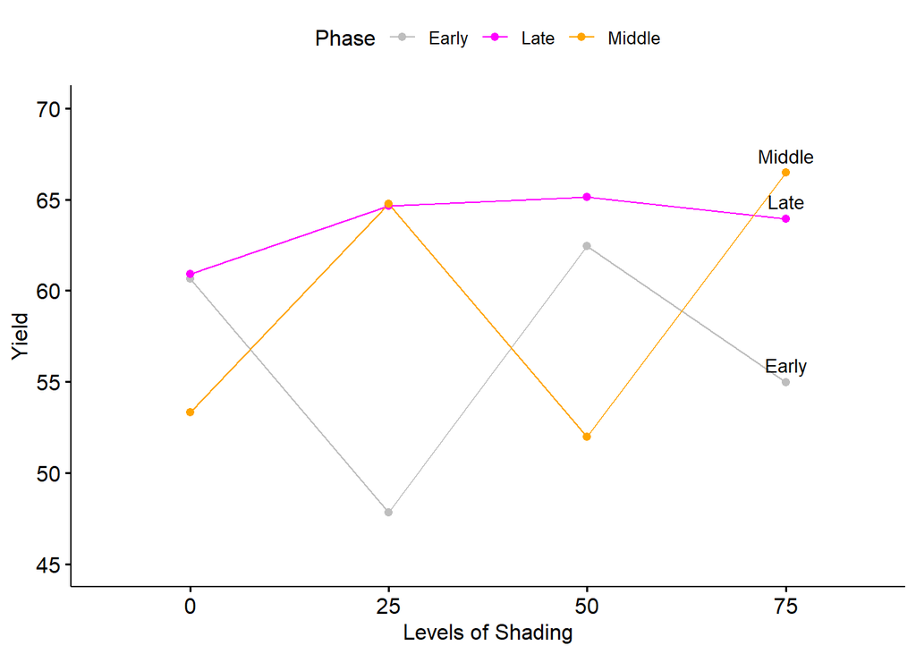

```r
# profile plot using ggline: Shade, Phase
profile <- ggline(clean_data, x = "PctShade", y = "Yield", color = "Phase",
       add = "mean",
       show.line.label = TRUE,
       label.rectangle = FALSE,
       palette = c("grey", "magenta", "orange"),
       xlab = "Levels of Shading",
       ylab = "Yield")
profile_plot <- ggpar(profile, ylim = c(45, 70))
profile_plot
```

2. If there is a main effect of shading, perform Tukey’s test to determine which levels of shading are significantly different. Test at the $\alpha=0.10$ level.

```r
# Two-way ANOVA
# Null Hypothesis:
# - H1: The means of observations grouped by Shade are the same
# - H2: The means of observations grouped by Phase are the same
# - H3: There is no interaction between Shade and Phase

summary(h1_h2 <- aov(clean_data$Yield ~ factor(clean_data$PctShade) + factor(clean_data$Phase)))
```

```
                            Df Sum Sq Mean Sq F value Pr(>F)
factor(clean_data$PctShade)  3     84   28.04   0.278 0.8407
factor(clean_data$Phase)     2    513  256.56   2.546 0.0932 .
Residuals                   34   3426  100.77
---
Signif. codes:  0 '***' 0.001 '**' 0.01 '*' 0.05 '.' 0.1 ' ' 1
```

```r
# Shade
#TukeyHSD(h1_h2, "factor(clean_data$PctShade)", conf.level = 0.90)
```

### Levels of Shading

3. If there is a main effect of phase of growth, perform Tukey’s test to determine which phases of growth are significantly different. Test at the $\alpha=0.10$ level.

```r
# Phase
TukeyHSD(h1_h2, "factor(clean_data$Phase)", conf.level = 0.90)
```

```
  Tukey multiple comparisons of means
    90% family-wise confidence level

Fit: aov(formula = clean_data$Yield ~ factor(clean_data$PctShade) + factor(clean_data$Phase))

$`factor(clean_data$Phase)`
                  diff         lwr       upr     p adj
Late-Early    8.360176   0.1491301 16.571222 0.0924787
Middle-Early  2.364375  -5.9973453 10.726094 0.8207827
Middle-Late  -5.995801 -14.2068473  2.215244 0.2806309
```

### Tukey’s Test for Phases of Growth

There is sufficient evidence at the $\alpha$=0.10 level to suggest a main effect between Early and Late phase.

4. Write a short paragraph to explain your results to the horticulturist.

## Conclusion

However, our recommendation suggests consistent performance in the late phase with a 50% level of shade.

Below are additional graphs to support our suggestion.

```r
# summary
summary(clean_data$Yield)
```

```
   Min. 1st Qu.  Median    Mean 3rd Qu.    Max.
  36.70   54.62   57.90   58.95   66.28   78.30
```

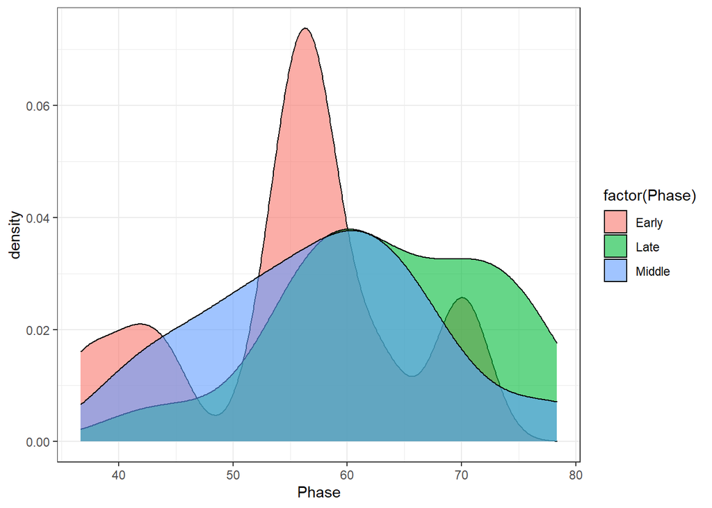

```r
# density plot: Phase
density_plot_phase <- clean_data %>%
  ggplot(aes(Yield, fill = factor(Phase)))+
  geom_density(alpha = 0.6)+
  xlab("Phase")+
  theme_bw()
density_plot_phase
```

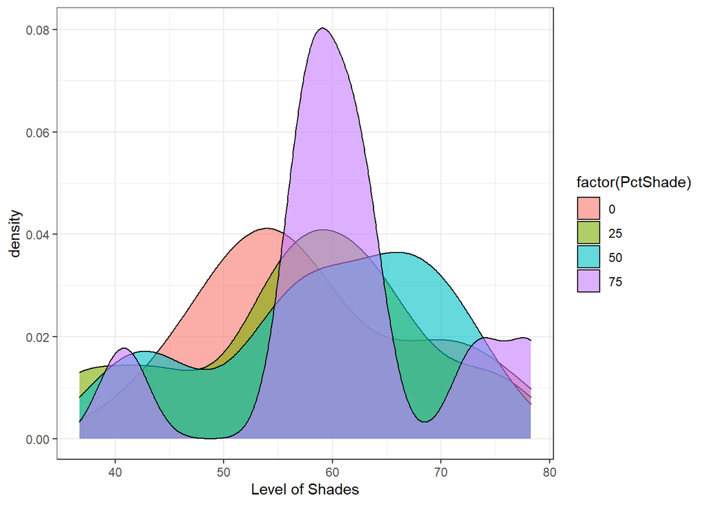

```r
# density plot: Shade
density_plot_shade <- clean_data %>%
  ggplot(aes(Yield, fill = factor(PctShade)))+
  geom_density(alpha = 0.6)+
  xlab("Level of Shades")+
  theme_bw()
density_plot_shade
```

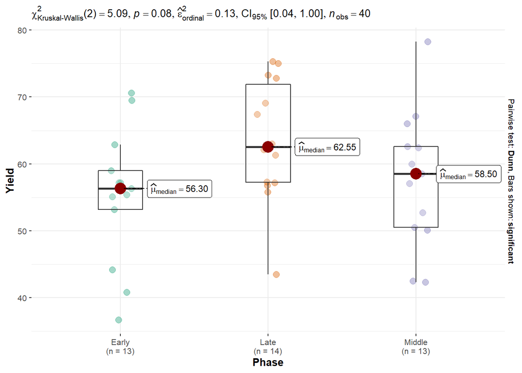

```r
# boxplot: Phase
ggbetweenstats(clean_data, x = Phase, y = Yield,
               plot.type = "box",
               type = "np",
               p.adjust.method = "bonferroni",
               pairwise.comparisons = TRUE,
               pairwise.display = "s")
```

5. Graphically assess the ANOVA assumptions – is ANOVA appropriate here?

We are unwilling to assume normality because we have found the assumption of normality invalid in diagnostic checks.

```r
# ANOVA summary
summary(two_anova <- aov(clean_data$Yield ~ factor(clean_data$PctShade) * factor(clean_data$Phase)))
```

```
                                                     Df Sum Sq Mean Sq F value
factor(clean_data$PctShade)                           3   84.1   28.04   0.310
factor(clean_data$Phase)                              2  513.1  256.56   2.835
factor(clean_data$PctShade):factor(clean_data$Phase)  6  891.8  148.64   1.642
Residuals                                            28 2534.3   90.51
                                                     Pr(>F)
factor(clean_data$PctShade)                          0.8181
factor(clean_data$Phase)                             0.0757 .
factor(clean_data$PctShade):factor(clean_data$Phase) 0.1726
Residuals
---
Signif. codes:  0 '***' 0.001 '**' 0.01 '*' 0.05 '.' 0.1 ' ' 1
```

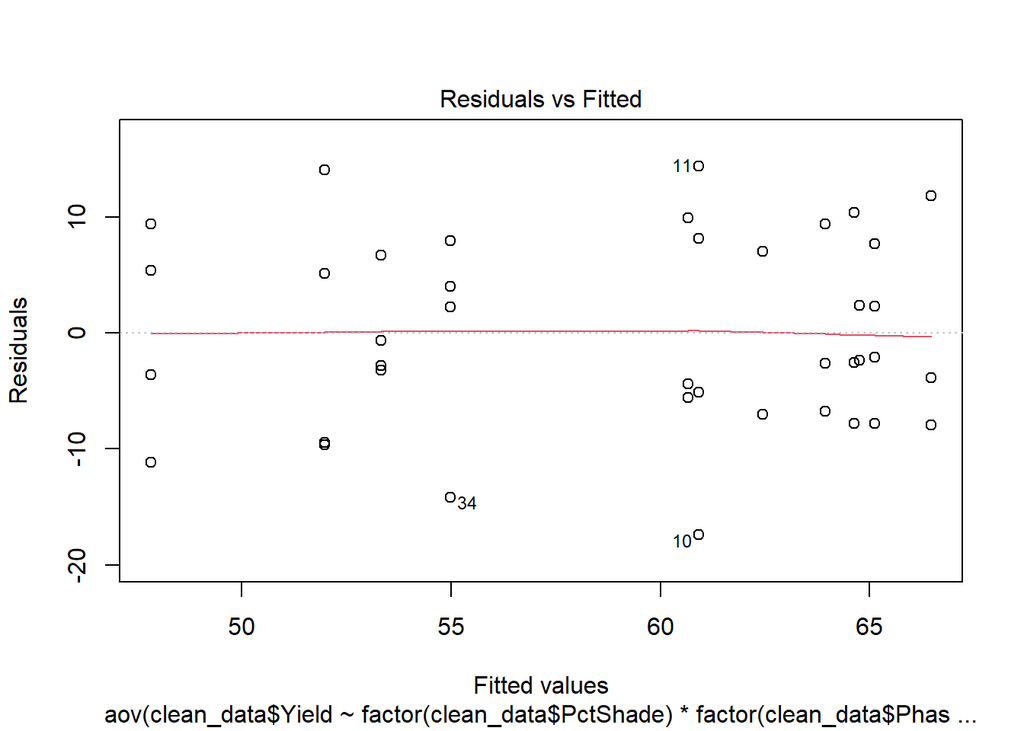

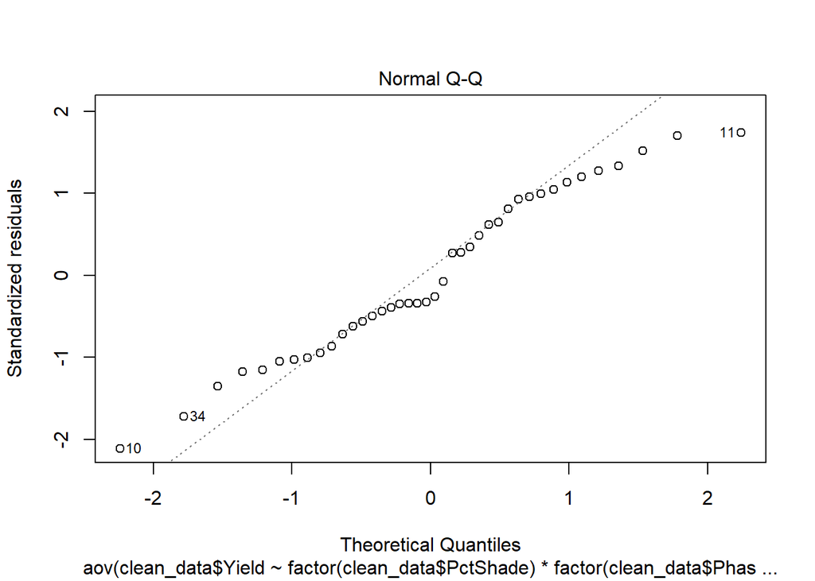

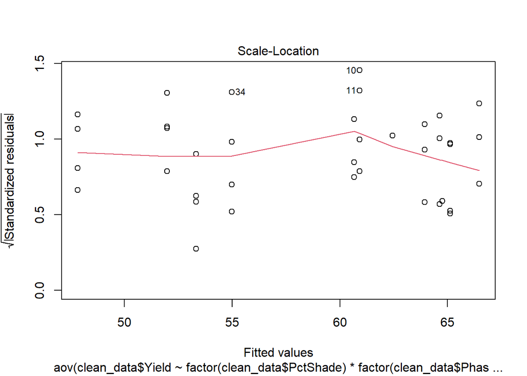

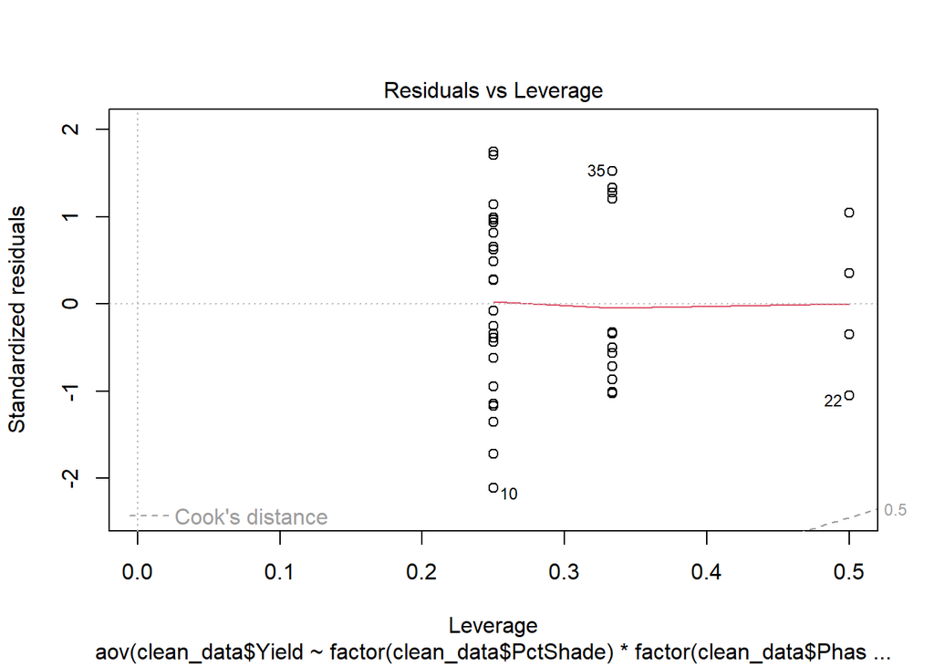

```r
# plots
plot(two_anova)
```